# Comparative analysis in Seurat v5

Compiled: 2026-11-05

load libraries

```r
library(Seurat)
library(BPCells)
library(tidyverse)
library(harmony)
library(viridisLite)
library(Azimuth)
# needs to be set for large dataset analysis
options(future.globals.maxSize = 1e9)
```

# This is a re-run of code from lesson 3

```r
#setwd("~/data")
# pre-processing workflow-----------------------------------------------------------------------------------------------------------------------------
Seurat_AD <- LoadSeuratRds('./Input_data/Eko_hippo.rds')
Seurat_WT <- LoadSeuratRds('./Input_data/WT_hippo.rds')
condition <- vector(mode="character", length=length(Seurat_AD$orig.ident))
condition [1:length(condition)] <- "AD"
Seurat_AD <- AddMetaData(object = Seurat_AD, metadata = condition, col.name = "condition")

condition <- vector(mode="character", length=length(Seurat_WT$orig.ident))
condition [1:length(condition)] <- "WT"
Seurat_WT <- AddMetaData(object = Seurat_WT, metadata = condition, col.name = "condition")

rm(condition)

# calculate mitochondrial gene content ------------------------------------------------------------------------------------------------------------------------
# The [[ operator can add columns to object metadata. This is a great place to stash QC stats
Seurat_WT[["percent.mt"]] <- PercentageFeatureSet(Seurat_WT, pattern = "^mt-")

# Filter out the bad quality cells ----------------------------------------------------------------------------------------------------------------------------
Seurat_WT <- subset(Seurat_WT, subset = nFeature_RNA < 2500 & nFeature_RNA > 200 & percent.mt < 5)

# normalize and scale -----------------------------------------------------------------------------------------------------------------------------------------
Seurat_WT <- NormalizeData(Seurat_WT)
```

```
## Normalizing layer: counts
```

```r
Seurat_WT <- FindVariableFeatures(Seurat_WT,
                                  selection.method = "vst",
                                  nfeatures = 2000)
```

```
## Finding variable features for layer counts
```

```r
Seurat_WT <- ScaleData(Seurat_WT)
# PCA and UMAP -----------------------------------------------------------------------------------------------------------------------------------------
Seurat_WT <- RunPCA(Seurat_WT, features = VariableFeatures(object = Seurat_WT), npcs = 250)
```

```
## PC_ 1
## Positive:  Meg3, Snhg11, Opcml, Pcsk2, Tenm2, Epha5, Grin2a, R3hdm1, Rnf112, Fam19a1
##     Chrm3, Atp2b1, 9530059O14Rik, PISD, Csmd2, Pex5l, Lrtm1, Cpne7, Rgs11, 5330434G04Rik
##     Zeb2, Chrd, Khdrbs2, Epha7, Nrxn3, Stxbp5l, Lrp1b, Lingo2, 3110035E14Rik, Chgb
## Negative:  Flt1, Hspb1, Cldn5, Slco1a4, Klf2, Pltp, Ly6c1, Rgs5, Igfbp7, Id1
##     Ly6a, Itm2a, Esam, Lsr, Abcb1a, Cxcl12, Epas1, Eng, Ifitm3, Emcn
##     Tm4sf1, Slco1c1, Acvrl1, Ctla2a, Adgrl4, Nfkbia, Ahnak, Id3, Myl12a, Fcgrt
## PC_ 2
## Positive:  Meg3, Snhg11, Flt1, Opcml, Hspb1, Slco1a4, Cldn5, Lsr, Klf2, Emcn
##     Rgs5, Pcsk2, Ly6c1, Esam, Ly6a, Acvrl1, Ctla2a, Eng, Tenm2, Itm2a
##     Pglyrp1, Adgrl4, Abcb1a, Cxcl12, Igfbp7, Sox18, Pltp, Gm694, Ly6e, Podxl
## Negative:  Plpp3, Gpr37l1, Slc1a3, Gja1, Atp1a2, F3, Apoe, Pla2g7, Clu, Ntsr2
##     Htra1, Mfge8, Slc7a10, Slc1a2, Ndrg2, Mlc1, Aqp4, Pax6, Mt2, Cst3
##     Btbd17, Aldoc, Cldn10, Tril, Pbxip1, Id4, Rorb, Phkg1, Bcan, Mt1
## PC_ 3
## Positive:  Cit, Maf, Slc32a1, Col19a1, Coro6, Nxph1, Slc6a1, Cacna2d2, Ankrd24, Mef2c
##     Kcnc1, Lrrtm3, Gad1, Tmem145, Gm13629, Snhg11, Gad2, Sst, Dlx6os1, Usp29
##     Zfp536, Vwa5b2, C1qa, Cntnap4, Sgcz, Hexb, C1qc, Csf1r, Camk1, Brinp3
## Negative:  Fam19a1, Zbtb20, Atp2b1, Rnf112, Grin2a, Gm44257, 4921539H07Rik, Chrd, Rnf182, Wipf3
##     Epha4, Cpne7, Pkp2, Wbscr17, Epha7, Hpca, Rasgrp1, Neurod6, Fibcd1, Plk2
##     Pantr1, Ntsr2, Pex5l, Neurod2, Wfs1, 3110035E14Rik, Zeb2, Chrm3, 9530059O14Rik, Cul4a
## PC_ 4
## Positive:  C1qa, Csf1r, C1qc, Selplg, Trf, Ctss, C1qb, Hexb, Plp1, Trem2
##     Mag, Olfml3, P2ry12, Laptm5, Zbtb20, Tmem119, Gpr34, Adap2os, Vsir, Neat1
##     Cx3cr1, Fcrls, Tgfbr1, C1ql3, Cldn11, Unc93b1, Fam19a1, Apod, Hk2, Hapln2
## Negative:  Snhg11, Cit, Coro6, Ntm, Slc32a1, Col19a1, Meg3, Maf, Ankrd24, Tle2
##     Sgcz, Vwa5b2, Npas1, Nxph1, Mir124-2hg, Tshz2, Cacna2d2, Dlx6os1, Rmst, Gad2
##     Gpc6, Brinp3, Elavl2, Ache, Elfn1, Slc6a1, Gm13629, Sst, Kcnc1, Serpini1
## PC_ 5
## Positive:  C1ql2, C1ql3, Synpr, Plk5, Tmem108, Dock10, Cntnap5a, Cald1, Prdm5, Onecut1
##     Lingo2, Ahcyl2, Lrrtm4, Rfx3, Ntng1, Negr1, Thsd7a, Pcdh8, Crlf1, Sema5a
##     Rasl10a, Tiam1, Jun, Prox1, Mef2c, Il1rap, Stxbp6, Gm12216, Pdzd2, Phxr4
## Negative:  Snhg11, Chrm3, Meg3, Cpne7, Pex5l, Ntm, Cpe, 3110035E14Rik, Sv2b, Rgs11
##     Pid1, Epha5, Kcnn2, 9530059O14Rik, Col11a1, Man1a, Sez6, Cul4a, Akap13, Plk2
##     5031439G07Rik, Lrtm1, Mgat4c, Neurod6, Rasgrp1, R3hdm1, Dkk3, Fezf2, Runx1t1, Pantr1
```

```r
Seurat_WT <- FindNeighbors(Seurat_WT,reduction = "pca", dims = 1:50)
Seurat_WT <- FindClusters(Seurat_WT, resolution = 1) # the higher the number the higher the clusters
```

```
## Modularity Optimizer version 1.3.0 by Ludo Waltman and Nees Jan van Eck
##
## Number of nodes: 5363
## Number of edges: 273289
##
## Running Louvain algorithm...
## Maximum modularity in 10 random starts: 0.8523
## Number of communities: 18
## Elapsed time: 0 seconds
```

```r
Seurat_WT <- RunUMAP(Seurat_WT, dims = 1:50)
```

# Run non-linear dimensional reduction (UMAP/tSNE)

Seurat offers several non-linear dimensional reduction techniques, such as tSNE and UMAP, to visualize and explore these datasets. The goal of these algorithms is to learn underlying structure in the dataset, in order to place similar cells together in low-dimensional space. Therefore, cells that are grouped together within graph-based clusters determined above should co-localize on these dimension reduction plots.

While we and others have routinely found 2D visualization techniques like tSNE and UMAP to be valuable tools for exploring datasets, all visualization techniques have limitations, and cannot fully represent the complexity of the underlying data. In particular, these methods aim to preserve local distances in the dataset (i.e. ensuring that cells with very similar gene expression profiles co-localize), but often do not preserve more global relationships. We encourage users to leverage techniques like UMAP for visualization, but to avoid drawing biological conclusions solely on the basis of visualization techniques.

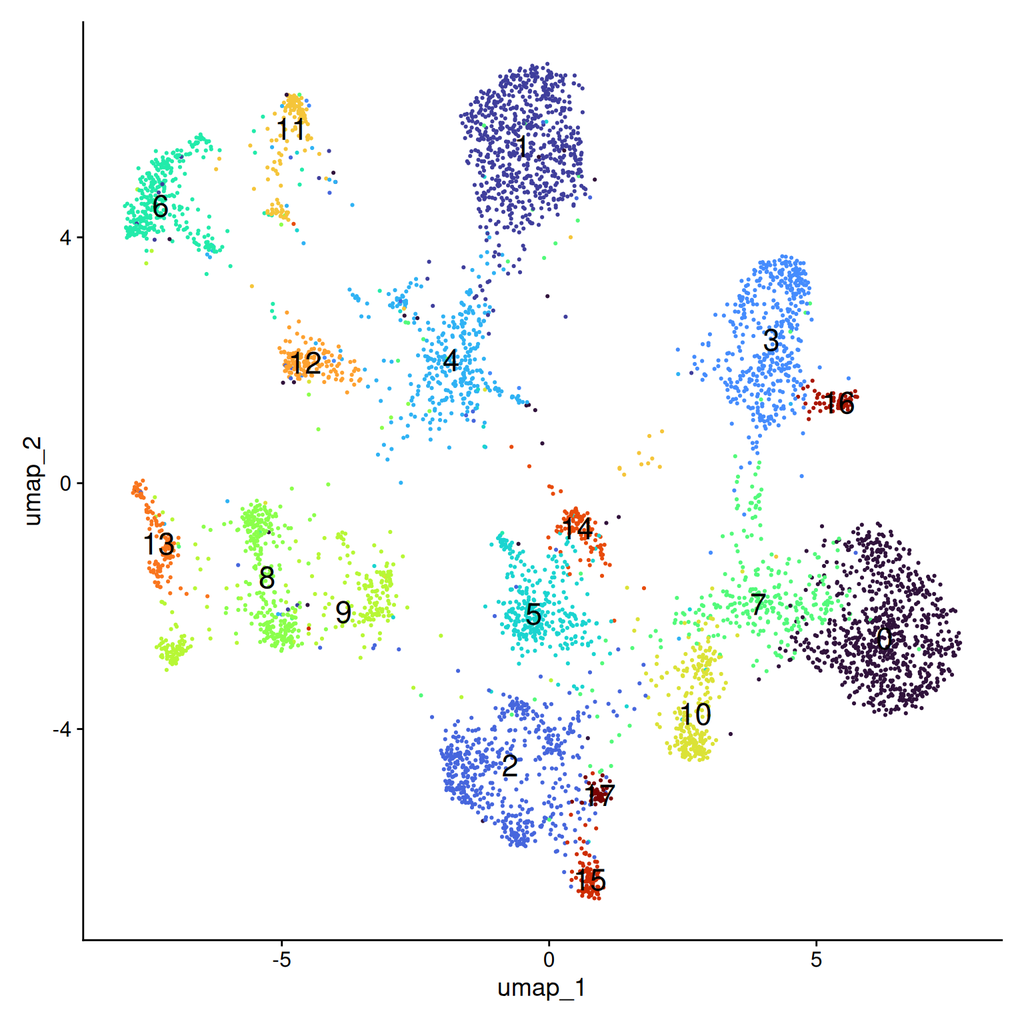

```r
N_clusters <-length(unique(Idents(Seurat_WT)))
# note that you can set `label = TRUE` or use the LabelClusters function to help label individual clusters
plot1 <- DimPlot(Seurat_WT, label = T, label.size = 6, reduction = 'umap', cols = turbo(N_clusters)) + NoLegend()
plot1
```

## Look at Features

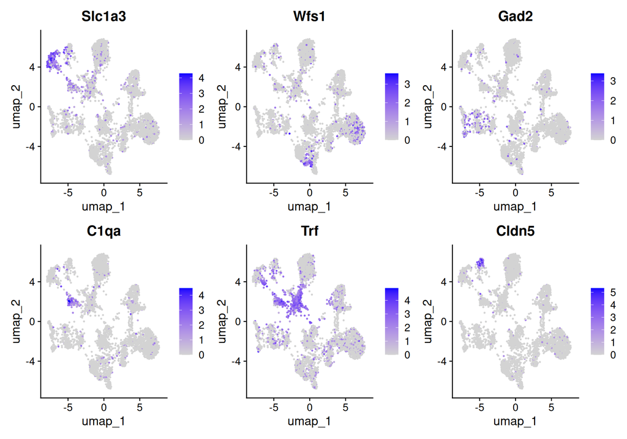

```r
FeaturePlot(
  object = Seurat_WT,
  features = c(
    "Slc1a3", #Astrocytes
    "Wfs1", # Glut Neurons or Slc17a7
    "Gad2", # GABA neurons
    "C1qa", # Microglia
    "Trf", # Myelin-forming mature oligodendrocytes
    "Cldn5"), # Endothelial cells
  ncol = 3)
```

## Differential gene expression

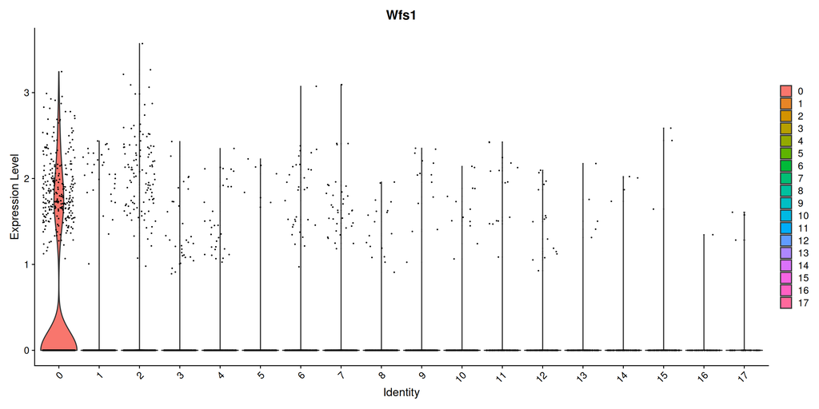

```r
VlnPlot(Seurat_WT, 'Wfs1')
```

This is to just prepare some marker genes Data taken from the publication

```r
# celltype_ 0: Wfs1+,Dcn+,Rxfp1- CA1 pyramidal neurons (Excitatory neuron 1)
celltype_0 <- c("Wfs1", "Dcn")

# celltype_ 1: C1ql2+ Granule cell of the dentate gyrus (Excitatory neuron 2)
celltype_1 <- c("C1ql2")

# celltype_ 2: Wfs1+,Dcn-,Rxfp1+ CA1 pyramidal neurons (Excitatory neuron 3)
celltype_2 <- c("Wfs1", "Rxfp1")

# celltype_ 3: Bok+ CA3 pyramidal neurons (Excitatory neuron 4)
celltype_3 <- c("Bok")

# celltype_ 4: Wfs1-,Dcn-, pyramidal neurons (Excitatory neuron 5)
celltype_4 <- c()  # no positive markers

# celltype_ 5: Sst+,Erbb4+ CA1 basket cells (Inhibitory neuron 1)
celltype_5 <- c("Sst", "Erbb4")

# celltype_ 6: Slc1a3+ Astrocytes
celltype_6 <- c("Slc1a3")

# celltype_ 7: Trf+ Myelin-forming mature oligodendrocytes (MFOLs)
celltype_7 <- c("Trf")

# celltype_ 8: Vip+,Reln+,Htr3a+,Erbb4+ CA1 basket cells (Inhibitory neuron 2)
celltype_8 <- c("Vip", "Reln", "Htr3a", "Erbb4")

# celltype_ 9: Ndst4+,Rxfp1+,Dcn- CA1 pyramidal neurons (Excitatory neuron 6)
celltype_9 <- c("Ndst4", "Rxfp1")

# celltype_ 10: C1qa+,Trf+ Microglia
celltype_10 <- c("C1qa", "Trf")

# celltype_ 11: Cldn5+ Endothelial cells
celltype_11 <- c("Cldn5")

# celltype_ 12: Htr2c+,Glra1-  CA1 pyramidal cells (Excitatory neuron 7)
celltype_12 <- c("Htr2c")

# celltype_ 13: Htr2c+,Glra1+ CA1 pyramidal cells (Inhibitory neuron 3)
celltype_13 <- c("Htr2c", "Glra1")

# celltype_ 14: Amigo2+ CA2 pyramidal neurons (Excitatory neuron 8)
celltype_14 <- c("Amigo2")

# celltype_ 15: Pdgfra+ Oligodendrocyte precursor cells (OPCs)
celltype_15 <- c("Pdgfra")

# celltype_ 16: Reln+,Dcn+ CA1 pyramidal cells (Excitatory neuron 9)
celltype_16 <- c("Reln", "Dcn")

# Combine all celltype_ vectors into one
all_genes <- c(
  celltype_0, celltype_1, celltype_2, celltype_3, celltype_4, celltype_5, celltype_6,
  celltype_7, celltype_8, celltype_9, celltype_10, celltype_11, celltype_12, celltype_13,
  celltype_14, celltype_15, celltype_16
)

# Remove duplicates
all_genes <- unique(all_genes)
```

## Finding differentially expressed features (cluster biomarkers)

Seurat can help you find markers that define clusters via differential expression (DE). By default, it identifies positive and negative markers of a single cluster (specified in ident.1), compared to all other cells. FindAllMarkers() automates this process for all clusters, but you can also test groups of clusters vs. each other, or against all cells.

The results data frame has the following columns : p_val : p-value (unadjusted) avg_log2FC : log fold-change of the average expression between the two groups. Positive values indicate that the feature is more highly expressed in the first group. pct.1 : The percentage of cells where the feature is detected in the first group pct.2 : The percentage of cells where the feature is detected in the second group p_val_adj : Adjusted p-value, based on Bonferroni correction using all features in the dataset. If the ident.2 parameter is omitted or set to NULL, FindMarkers() will test for differentially expressed features between the group specified by ident.1 and all other cells. Additionally, the parameter only.pos can be set to TRUE to only search for positive markers, i.e. features that are more highly expressed in the ident.1 group.

In Seurat v5, we use the presto package (as described here and available for installation here), to dramatically improve the speed of DE analysis, particularly for large datasets. For users who are not using presto, you can examine the documentation for this function (?FindMarkers) to explore the min.pct and logfc.threshold parameters, which can be increased in order to increase the speed of DE testing.

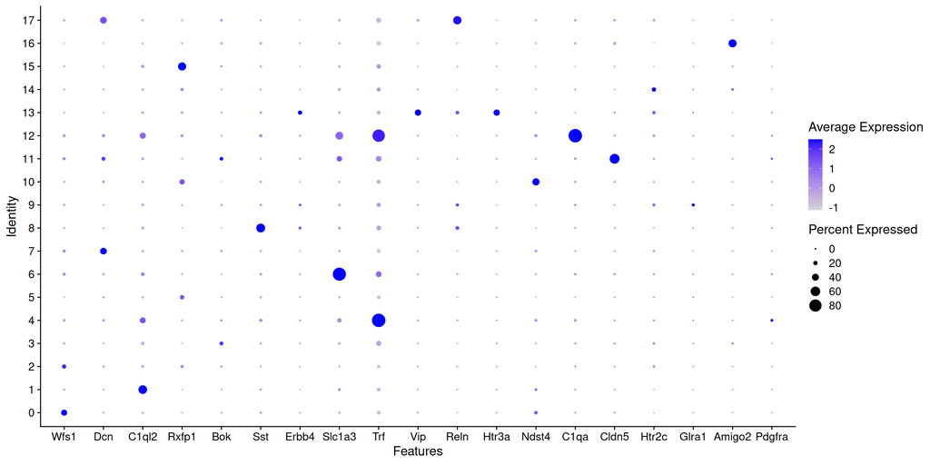

```r
DotPlot(Seurat_WT, features= all_genes)
```

```r
# find all markers of cluster 6
Idents(Seurat_WT) <- "seurat_clusters"
cluster6.markers <- FindMarkers(Seurat_WT, ident.1 = "6", only.pos = TRUE)
head(cluster6.markers, n = 10)
```

|  | p_val | avg_log2FC | pct.1 | pct.2 | p_val_adj |
| --- | --- | --- | --- | --- | --- |
| Atp1a2 | 0 | 4.606372 | 0.948 | 0.136 | 0 |
| Plpp3 | 0 | 5.181309 | 0.893 | 0.098 | 0 |
| Slc1a3 | 0 | 4.735494 | 0.865 | 0.099 | 0 |
| Gpr37l1 | 0 | 5.173775 | 0.838 | 0.077 | 0 |
| Gja1 | 0 | 5.140401 | 0.807 | 0.066 | 0 |
| F3 | 0 | 4.879141 | 0.593 | 0.044 | 0 |
| Pla2g7 | 0 | 4.496007 | 0.755 | 0.088 | 0 |
| Slc7a10 | 0 | 4.936422 | 0.563 | 0.038 | 0 |
| Mfge8 | 0 | 4.612856 | 0.676 | 0.068 | 0 |
| Ntsr2 | 0 | 4.252236 | 0.826 | 0.130 | 0 |

### Plot the markers

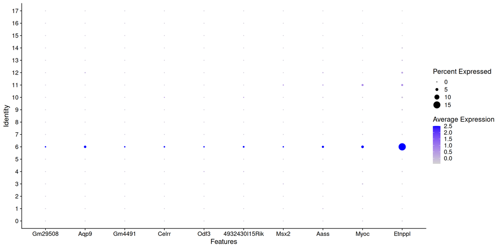

```r
cluster6.markers %>%
    dplyr::filter(avg_log2FC > 2 & p_val < 0.05) %>%
    slice_max(avg_log2FC, n = 10) -> top10

Idents(Seurat_WT) <- "seurat_clusters"
DotPlot(Seurat_WT, features = rownames(top10))
```

# Azimuth

Automated naming of clusters

```r
Seurat_WT <- RunAzimuth(Seurat_WT, reference = "mousecortexref")
```

```
## detected inputs from MOUSE with id type Gene.name
```

```
## reference rownames detected MOUSE with id type Gene.name
```

```
## Normalizing query using reference SCT model
```

```
## Only one SCT model detected; no need to select.
```

```
## Projecting cell embeddings
```

```
## Finding query neighbors
```

```
## Finding neighborhoods
```

```
## Finding anchors
```

```
##  Found 859 anchors
```

```
## Finding integration vectors
```

```
## Finding integration vector weights
```

```
## Predicting cell labels
## Predicting cell labels
## Predicting cell labels
## Predicting cell labels
```

```
##
## Integrating dataset 2 with reference dataset
```

```
## Finding integration vectors
```

```
## Integrating data
```

```
## Running UMAP projection
```

```
## 12:37:03 Processing block 1 of 1
```

[output not shown]

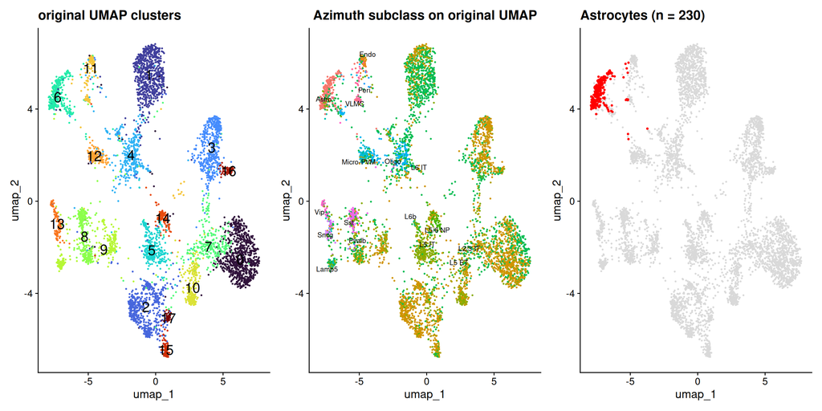

```r
ct <- "predicted.subclass"

p1 <- DimPlot(Seurat_WT, label = T, label.size = 6, reduction = 'umap', cols = turbo(N_clusters)) + NoLegend() +  ggtitle("original UMAP clusters")

p2 <- DimPlot(Seurat_WT, reduction = "umap", group.by = ct,
              label = TRUE, repel = TRUE, label.size = 3) +
  ggtitle("Azimuth subclass on original UMAP") + NoLegend()

# highligh the specific cell type
cells_to_highlight <- WhichCells(Seurat_WT, expression = predicted.subclass == "Astro")
p3 <- DimPlot(Seurat_WT, reduction = "umap",
        cells.highlight = cells_to_highlight,
        cols.highlight = "red", cols = "grey85",
        sizes.highlight = 0.6) +
  ggtitle(paste0("Astrocytes (n = ", length(cells_to_highlight), ")")) +
  NoLegend()

p1 + p2 +p3
```

```r
tab <- table(Seurat = Seurat_WT$seurat_clusters,
             Azimuth = Seurat_WT$predicted.subclass)
tab
```

```
##       Azimuth
## Seurat Astro Endo L2/3 IT L5 ET L5 IT L5/6 NP L6 IT L6b Lamp5 Micro-PVM Oligo
##     0      0    0     484    25    72       2   225   0     0         1     0
##     1      0    0     128    14    79       0   489   0     0         0     0
##     2      0    0     426     3    61      17    48   0     0         1     0
##     3      0    0     292     7    44       0   122   0     0         0     0
##     4      1    0      35     4    11       1   183   0     0         0    99
##     5      0    0      38     4   229      13    36  10     0         0     0
##     6    223    0       5     1    16       0    56   0     1         0    19
##     7      0    0     108    50    34       1   116   0     0         0     0
##     8      0    0      50     0    87       0    74   0     1         0     1
##     9      0    0      76    14    86       1    60   0    25         0     0
##     10     0    0      69    62    80       1    28   0     0         0     0
##     11     6   56       4     0     1       0    26   0     0         1     5
##     12     0    0      12     2     3       1    23   0     0        75    25
```

[output cut: 25 more lines]

# Export data to MapMyCells

We will export the count matrix and map the cells with Allen Brain atlas see: https://portal.brain-map.org/atlases-and-data/bkp/mapmycells use: https://knowledge.brain-map.org/mapmycells/process/ ## Extract the Count Matrix

```r
mat <- GetAssayData(object = subset(Seurat_WT, downsample = 1000, subset = seurat_clusters %in% c(6)), assay = "RNA", layer = "counts")
# we need to transpose the matrix, as MapMyCells expects matrix in which rows are "cells" and columns are genes!
mat_t <- t(mat)
write.csv(mat_t, "./count_matrix_cluster6.csv")
```

# Manual rename

Here we will do a manual rename of some clusters

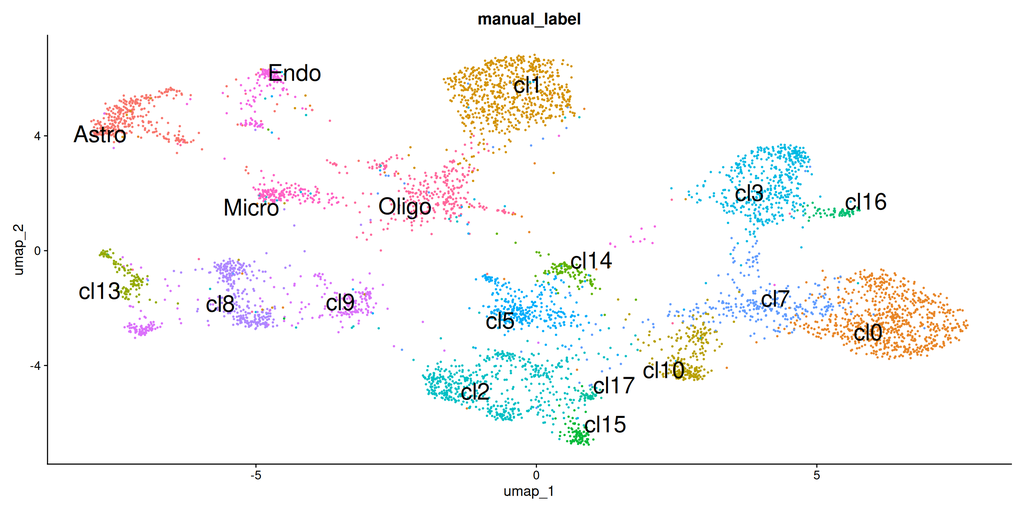

```r
# Manual assigment of seaurat clusters to names
lab <- c("6" = "Astro", "4" = "Oligo", "11" = "Endo", "12" = "Micro")
cl  <- as.character(Seurat_WT$seurat_clusters)

Seurat_WT$manual_label <- ifelse(cl %in% names(lab), lab[cl], paste0("cl", cl))

DimPlot(Seurat_WT, group.by = "manual_label", label = TRUE, repel = TRUE, label.size = 8) + NoLegend()
```

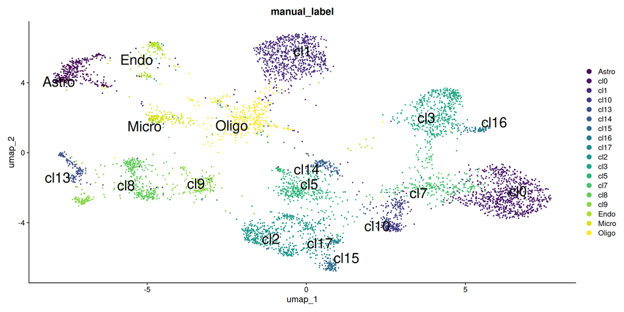

```r
# different colors
n   <- length(unique(Idents(Seurat_WT)))      # or the number of levels of your group.by column
cols <- viridis(n, option = "D")

DimPlot(Seurat_WT, reduction = "umap", group.by = "manual_label",
        cols = cols, label = TRUE, repel = TRUE, label.size = 8)
```